# QUD Kids

Hugh Rabagliati

5 November 2014

Working Directory should be “AdultExperiment”.

*Action data*

We read in action data from a single Excel spreadsheet, and then graph it and analyze it.

1. Read in the data
2. Graph the data

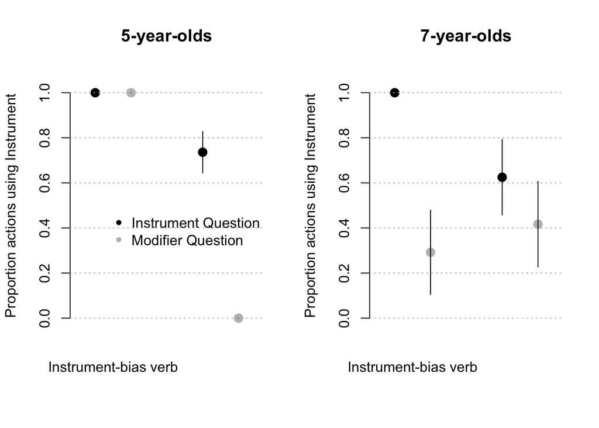

```r
k <- summaryBy(Instr~QuestCond+VerbCond+Age+Participant.no, data = qud.a, FUN = c(mean,sd))
k <- summaryBy(Instr.mean~QuestCond+VerbCond+Age, data = k, FUN = c(mean,sd))
k$SE = k$Instr.mean.sd/sqrt(6)
k$VerbCond = factor(k$VerbCond, levels(k$VerbCond)[c(2,1)])
tapply(k$Instr.mean.mean, list(k$QuestCond,k$VerbCond,k$Age), FUN = mean) -> o
tapply(k$SE, list(k$QuestCond,k$VerbCond,k$Age), FUN = mean) -> se
old.par <- par(mfrow=c(1, 2))
 barplot(o[,,1], beside =T , ylim = c(-0.1,1.1),col = "white",  border = NA, ylab = "Proportion actions using Instrument",  main = "5-year-olds",names.arg = c("Instrument-bias verb", "Equi-bias verb"))
 legend(1.8,0.5, legend = c("Instrument Question", "Modifier Question"), bty = "n", col = c("black","grey"), pch = 20)
 points(c(1.5,4.5), o[1,,1], pch = 20, cex = 2, col = "black")
 points(c(2.5,5.5), o[2,,1], pch = 20, cex = 2, col = "grey")
 grid(nx = NA, ny = NULL, col = "gray", lty = "dotted",lwd = par("lwd"), equilogs = TRUE)
  arrows(c(1.5,2.5,4.5,5.5), (c(o[,,1]) + c(se[,,1])), c(1.5,2.5,4.5,5.5), (c(o[,,1]) - c(se[,,1])), code = 0)

 barplot(o[,,2], beside =T , ylim = c(-0.1,1.1),col = "white",  border = NA, ylab = "Proportion actions using Instrument",  main = "7-year-olds",names.arg = c("Instrument-bias verb", "Equi-bias verb"))
 points(c(1.5,4.5), o[1,,2], pch = 20, cex = 2, col = "black")
 points(c(2.5,5.5), o[2,,2], pch = 20, cex = 2, col = "grey")
 grid(nx = NA, ny = NULL, col = "gray", lty = "dotted",lwd = par("lwd"), equilogs = TRUE)
 arrows(c(1.5,2.5,4.5,5.5), (c(o[,,2]) + c(se[,,2])), c(1.5,2.5,4.5,5.5), (c(o[,,2]) - c(se[,,2])), code = 0)
```

```r
 par(old.par)
```

Analyzing this data turned out to be hard, because we have considerable “separation” - where a predictor perfectly separates two groups of data (ie our experiment worked too well!). We began by trying to use logistic regression, but the separation meant that it wouldnt fit. So, we used ANOVAs, calculating p values by permutation. To avoid this document taking all day to generate, we just use 100 permutations here.

Our ANOVA is 2 (age) * 2(QUD) * 2 (verb bias), and the print out at the end is a standard ANOVA, and then the set of permutation-derived p values.

```
##                        Df Sum Sq Mean Sq F value  Pr(>F)
## Age                     1   0.12   0.122    1.50 0.22716
## VerbCond                1   1.72   1.719   21.25 4.1e-05 ***
## QuestCond               1   2.05   2.049   25.33 1.1e-05 ***
## Age:VerbCond            1   0.77   0.771    9.53 0.00366 **
## Age:QuestCond           1   0.02   0.024    0.30 0.58549
## VerbCond:QuestCond      1   0.04   0.042    0.52 0.47631
## Age:VerbCond:QuestCond  1   1.15   1.146   14.17 0.00054 ***
## Residuals              40   3.23   0.081
## ---
## Signif. codes:  0 '***' 0.001 '**' 0.01 '*' 0.05 '.' 0.1 ' ' 1
```

```
## [1] 0.25
## [1] 0.01
## [1] 0.01
## [1] 0.02
## [1] 0.61
## [1] 0.5
## [1] 0.01
```

*** Eye tracking graphs and analysis***

To process the data for analysis (take in the Excel files, expand them over timepoints), we need to load in the scripts in the proc_subj.r, ET_Import.r and Graphing.r files. Once that’s done, we run the first set of code in QUD_Summary, which produces the dataframe QUD_Expand. That can also be loaded up, as below.

```r
load("QUD_Expand_Child.RDATA")
```

We’ll need to import some libraries for plotting etc.

```
## gdata: read.xls support for 'XLS' (Excel 97-2004) files ENABLED.
##
## gdata: read.xls support for 'XLSX' (Excel 2007+) files ENABLED.
##
##
##
##
```

And now construct and then melt the dataframes that we use for plotting

```r
se <- function(x){
  x <- sd(x)/sqrt(6)
    return(x)
    }

QUD.Graph <- summaryBy(Inst+TA+DA+DI~TimeFrame+Cond+QCond+Name.+Age, data = QUD.Expand[QUD.Expand$TimeFrame > -300 & QUD.Expand$TimeFrame <=1500,], FUN = c(mean),keep.names = T)
QUD.Graph <- summaryBy(Inst+TA+DA+DI~TimeFrame+Cond+QCond+Age, data = QUD.Graph, FUN = c(mean,se))
levels(QUD.Graph$QCond)[levels(QUD.Graph$QCond)=="Inst"] <- "Instrument Question"
levels(QUD.Graph$QCond)[levels(QUD.Graph$QCond)=="Mod"] <- "Modifier Question"
levels(QUD.Graph$Cond)[levels(QUD.Graph$Cond)=="Inst"] <- "Instrument-bias Verbs"
levels(QUD.Graph$Cond)[levels(QUD.Graph$Cond)=="Equi"] <- "Equi-bias Verbs"
QUD.Graph$Cond <- relevel(QUD.Graph$Cond, "Instrument-bias Verbs")
QUD.Graph$QCond <- relevel(QUD.Graph$QCond, "Instrument Question")

QUD.Graph2 <- melt(QUD.Graph,
        # ID variables - all the variables to keep but not split apart on
    id.vars=c("TimeFrame","Cond","QCond","Age"),
        # The source columns
    measure.vars=c("Inst.mean","TA.mean", "DA.mean", "DI.mean" ),
        # Name of the destination column that will identify the original
        # column that the measurement came from
    value.name="Prop",
    variable.name ="Quadrant"
    )
QUD.Graph2$Quadrant <- revalue(QUD.Graph2$Quadrant, c("Inst.mean"="Target Instrument", "TA.mean"="Target Animal", "DA.mean" = "Distractor Animal","DI.mean" = "Distractor Instrument"))
QUD.Graph2$Quadrant <- ordered(QUD.Graph2$Quadrant, levels = c("Target Animal", "Distractor Animal", "Target Instrument", "Distractor Instrument"))
```

And then plot our graphs. The first graph plots mean prop of trials looking at the instrument over the time.

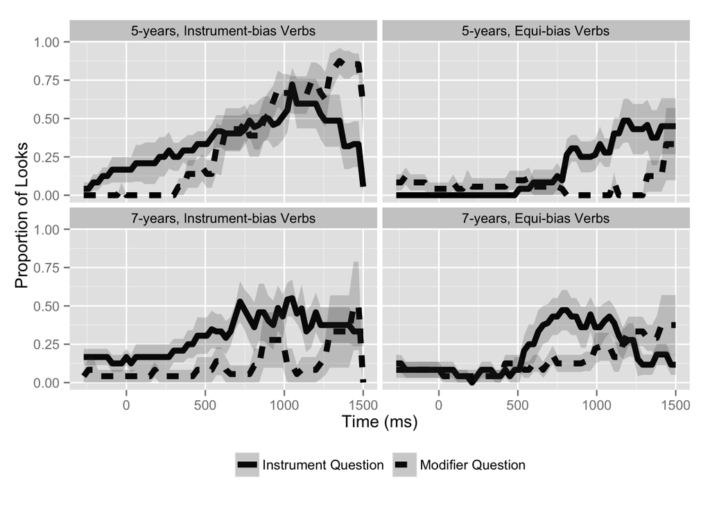

```r
ggplot(QUD.Graph,aes(TimeFrame,Inst.mean,linetype = QCond)) + facet_wrap(~Age+Cond) + stat_summary(fun.y = mean, geom = "line", size = 2) + geom_ribbon(aes(ymin=(Inst.mean - Inst.se), ymax=(Inst.mean + Inst.se)), alpha=0.2)+ theme(legend.title=element_blank(),legend.position="bottom")+labs(x = "Time (ms)",y = "Proportion of Looks")
```

The second plot is a standard spaghetti plot, showing looks to each different quadrant.

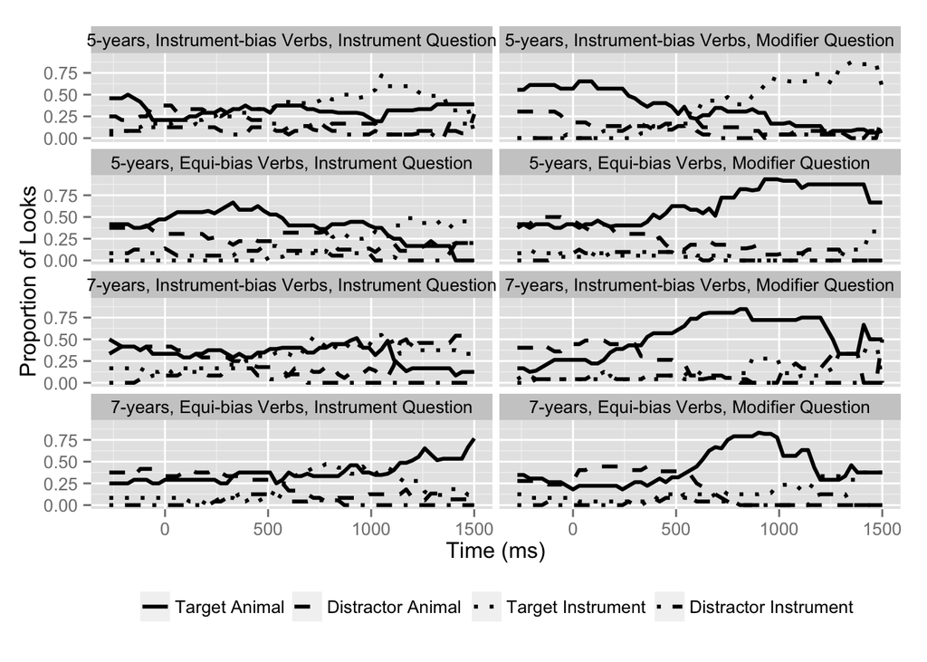

```r
ggplot(QUD.Graph2,aes(TimeFrame,Prop,linetype = Quadrant)) + facet_wrap(~Age+Cond+QCond, nrow = 4, ncol = 2) + stat_summary(fun.y = mean, geom = "line", size = 1) + theme(legend.title=element_blank(),legend.position="bottom")+ theme(legend.title=element_blank(),legend.position="bottom")+scale_linetype_manual(values=c(1,2,3,4))+labs(x = "Time (ms)",y = "Proportion of Looks")
```

To *analyze* this data, we split it into two 500ms time windows, beginning 200 and 700ms after the onset of the target word.

```r
QUD.Expand$Window <- as.factor(ifelse(QUD.Expand$TimeFrame <700, "EarlyWindow","LateWindow"))
QUD.Window <- summaryBy(Inst~Cond+QCond+Trial+Name.+Age+Window, data = QUD.Expand[QUD.Expand$TimeFrame > 200 & QUD.Expand$TimeFrame < 1200,], FUN = c(mean),keep.names = T,na.rm = T)
QUD.Window$Inst <- ifelse(QUD.Window$Inst > 0,1,0)
contrasts(QUD.Window$QCond)[1] <- -1
contrasts(QUD.Window$Age)[1] <- -1
contrasts(QUD.Window$Cond)[1] <- -1
contrasts(QUD.Window$Window)[1] <- -1
summaryBy(Inst~Age+Window+Cond+QCond, data = QUD.Window)
```

```
##        Age      Window Cond QCond Inst.mean
## 1  5-years EarlyWindow Equi   Mod   0.14286
## 2  5-years EarlyWindow Equi  Inst   0.08696
## 3  5-years EarlyWindow Inst   Mod   0.38095
## 4  5-years EarlyWindow Inst  Inst   0.54167
## 5  5-years  LateWindow Equi   Mod   0.11765
## 6  5-years  LateWindow Equi  Inst   0.47619
## 7  5-years  LateWindow Inst   Mod   0.61111
## 8  5-years  LateWindow Inst  Inst   0.73913
## 9  7-years EarlyWindow Equi   Mod   0.21739
## 10 7-years EarlyWindow Equi  Inst   0.45833
## 11 7-years EarlyWindow Inst   Mod   0.13043
## 12 7-years EarlyWindow Inst  Inst   0.45833
## 13 7-years  LateWindow Equi   Mod   0.31818
## 14 7-years  LateWindow Equi  Inst   0.63636
## 15 7-years  LateWindow Inst   Mod   0.15000
## 16 7-years  LateWindow Inst  Inst   0.81818
```

We plot a graph

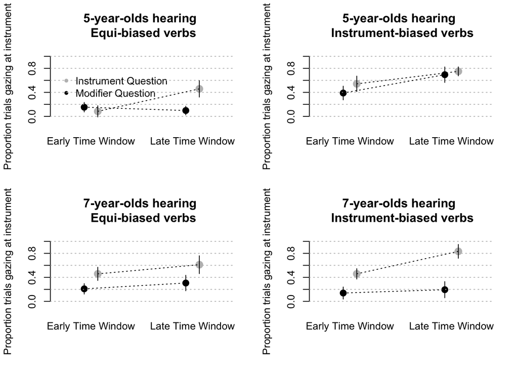

```r
k <- summaryBy(Inst~QCond+Cond+Age+Name.+Window, data = QUD.Window, FUN = c(mean,sd))
k <- summaryBy(Inst.mean~QCond+Cond+Age+Window, data = k, FUN = c(mean,sd))
k$SE = k$Inst.mean.sd/sqrt(6)
tapply(k$Inst.mean.mean, list(k$QCond,k$Window,k$Cond,k$Age), FUN = mean) -> o
tapply(k$SE, list(k$QCond,k$Window,k$Cond,k$Age), FUN = mean) -> se

old.par <- par(mfrow=c(2, 2))
for (i in c(1:2)){
  for (j in c(1:2)){
 barplot(o[,,1,1], beside =T , ylim = c(-0.1,1.1),col = "white",  border = NA, ylab = "Proportion trials gazing at instrument",  names.arg = c("Early Time Window", "Late Time Window"))
 if (i == 1){
    if (j == 1){
     title(main = "5-year-olds hearing \n Equi-biased verbs")
     legend(1,0.8, legend = c("Instrument Question","Modifier Question"),  bty = "n", col = c("grey","black"), pch = 20)
     }else{
     title(main = "5-year-olds hearing \n Instrument-biased verbs")}
     }else{
     if (j ==1){
     title(main = "7-year-olds hearing \n Equi-biased verbs")
     }else{
     title(main = "7-year-olds hearing \n Instrument-biased verbs")
     }
     }
 points(c(1.8,4.8), o[1,,j,i], pch = 20, cex = 2, col = "black")
 points(c(2.2,5.2), o[2,,j,i], pch = 20, cex = 2, col = "grey",lwd = 2)
 grid(nx = NA, ny = NULL, col = "gray", lty = "dotted",lwd = par("lwd"), equilogs = TRUE)
  arrows(c(1.8,2.2,4.8,5.2), (c(o[,,j,i]) + c(se[,,j,i])+0.01), c(1.8,2.2,4.8,5.2),  (c(o[,,j,i]) - c(se[,,j,i])-0.01), code = 0)
lines(c(1.8,4.8), o[1,,j,i], pch = 15, cex = 5, col = "black", lty = 3)
lines(c(2.2,5.2), o[2,,j,i], pch = 15, cex = 5, col = "black", lty = 3)
}
}
```

```r
par(old.par)
```

We run our stats on each time window.

```r
# Overall
summary(glmer(Inst~Age*Cond*QCond*Window + (1|Name.) +(0+Window|Name.)+ (1|Trial)+(0+QCond+Window+Age|Trial), data = QUD.Window, family = "binomial",control=glmerControl(optCtrl=list(maxfun=20000), optimizer = "bobyqa" )))
```

```
## Generalized linear mixed model fit by maximum likelihood (Laplace
##   Approximation) [glmerMod]
##  Family: binomial  ( logit )
## Formula: Inst ~ Age * Cond * QCond * Window + (1 | Name.) + (0 + Window |
##     Name.) + (1 | Trial) + (0 + QCond + Window + Age | Trial)
##    Data: QUD.Window
## Control:
## glmerControl(optCtrl = list(maxfun = 20000), optimizer = "bobyqa")
##
##      AIC      BIC   logLik deviance df.resid
##    412.2    531.6   -175.1    350.2      317
##
## Scaled residuals:
##    Min     1Q Median     3Q    Max
## -3.217 -0.505 -0.208  0.494  2.700
##
## Random effects:
##  Groups  Name              Variance Std.Dev. Corr
##  Name.   (Intercept)       1.96e-14 1.40e-07
##  Name..1 WindowEarlyWindow 7.23e-01 8.50e-01
##          WindowLateWindow  1.75e+00 1.32e+00 1.00
##  Trial   (Intercept)       0.00e+00 0.00e+00
##  Trial.1 QCondMod          7.81e-01 8.84e-01
##          QCondInst         1.93e+00 1.39e+00  0.89
##          WindowLateWindow  1.19e-01 3.46e-01  0.99  0.95
##          Age7-years        1.28e-01 3.58e-01 -0.33 -0.72 -0.48
## Number of obs: 348, groups:  Name., 48; Trial, 8
##
## Fixed effects:
##                                                Estimate Std. Error z value
## (Intercept)                                     -0.7784     0.4635   -1.68
## Age7-years                                       0.1445     0.2715    0.53
## CondInst                                         0.6879     0.4632    1.49
## QCondInst                                        0.8280     0.2770    2.99
## WindowLateWindow                                 0.5142     0.2135    2.41
## Age7-years:CondInst                             -0.7502     0.2787   -2.69
## Age7-years:QCondInst                             0.4649     0.2336    1.99
## CondInst:QCondInst                               0.2558     0.2663    0.96
## Age7-years:WindowLateWindow                     -0.0501     0.1635   -0.31
## CondInst:WindowLateWindow                        0.1037     0.2139    0.48
```

[output cut: 44 more lines]

```
## Age7-years
## CondInst
## QCondInst
## WindwLtWndw
## Ag7-yrs:CnI
## Ag7-yrs:QCI
## CndInst:QCI
## Ag7-yrs:WLW
## CndInst:WLW  0.208
## QCndIns:WLW  0.003  0.086
## Ag7-:CI:QCI  0.069  0.109  0.062
## Ag7-:CI:WLW -0.131 -0.147 -0.173 -0.083
## A7-:QCI:WLW -0.051  0.002  0.023  0.077      -0.092
## CnI:QCI:WLW -0.062 -0.039 -0.079  0.044      -0.036    0.249
## A7-:CI:QCI: -0.035  0.022  0.298  0.270      -0.113   -0.067   -0.073
```

```r
#Stats
#Early window
summary(glmer(Inst~Age*Cond*QCond + (1|Name.) + (1|Trial)+(0+QCond+Age|Trial), data = subset(QUD.Window, Window == "EarlyWindow"), family = "binomial",control=glmerControl(optCtrl=list(maxfun=20000), optimizer = "bobyqa" )))
```

```
## Generalized linear mixed model fit by maximum likelihood (Laplace
##   Approximation) [glmerMod]
##  Family: binomial  ( logit )
## Formula: Inst ~ Age * Cond * QCond + (1 | Name.) + (1 | Trial) + (0 +
##     QCond + Age | Trial)
##    Data: subset(QUD.Window, Window == "EarlyWindow")
## Control:
## glmerControl(optCtrl = list(maxfun = 20000), optimizer = "bobyqa")
##
##      AIC      BIC   logLik deviance df.resid
##    230.6    281.9    -99.3    198.6      167
##
## Scaled residuals:
##    Min     1Q Median     3Q    Max
## -1.544 -0.678 -0.387  0.925  3.252
##
## Random effects:
##  Groups  Name        Variance Std.Dev. Corr
##  Name.   (Intercept) 0.0000   0.000
##  Trial   (Intercept) 0.0000   0.000
##  Trial.1 QCondMod    0.0348   0.187
##          QCondInst   0.3564   0.597     1.00
##          Age7-years  0.0107   0.103    -1.00 -1.00
## Number of obs: 183, groups:  Name., 48; Trial, 8
##
## Fixed effects:
##                               Estimate Std. Error z value Pr(>|z|)
## (Intercept)                     -1.033      0.241   -4.29  1.8e-05 ***
## Age7-years                       0.149      0.200    0.75   0.4549
## CondInst                         0.440      0.242    1.82   0.0690 .
## QCondInst                        0.343      0.208    1.65   0.0985 .
## Age7-years:CondInst             -0.591      0.201   -2.95   0.0032 **
## Age7-years:QCondInst             0.362      0.193    1.88   0.0605 .
## CondInst:QCondInst               0.257      0.208    1.23   0.2177
## Age7-years:CondInst:QCondInst   -0.102      0.194   -0.52   0.6012
## ---
## Signif. codes:  0 '***' 0.001 '**' 0.01 '*' 0.05 '.' 0.1 ' ' 1
##
## Correlation of Fixed Effects:
##             (Intr) Ag7-yr CndIns QCndIn Ag7-:CI A7-:QC CI:QCI
## Age7-years  -0.262
## CondInst    -0.161  0.270
## QCondInst    0.186 -0.257 -0.132
## Ag7-yrs:CnI  0.270 -0.225 -0.269  0.058
## Ag7-yrs:QCI -0.169 -0.029  0.047 -0.160 -0.160
## CndInst:QCI -0.134  0.060  0.197 -0.191 -0.269   0.295
## Ag7-:CI:QCI  0.052 -0.166 -0.181  0.297 -0.012  -0.208 -0.170
```

```r
#Produces interaction btwn age and VerbCond
#Check each age group
summary(glmer(Inst~Cond*QCond + (1|Name.) + (1|Trial)+(0+QCond|Trial), data = subset(QUD.Window, Window == "EarlyWindow" & Age == "5-years"), family = "binomial",control=glmerControl(optCtrl=list(maxfun=20000), optimizer = "bobyqa" )))
```

```
## Generalized linear mixed model fit by maximum likelihood (Laplace
##   Approximation) [glmerMod]
##  Family: binomial  ( logit )
## Formula: Inst ~ Cond * QCond + (1 | Name.) + (1 | Trial) + (0 + QCond |
##     Trial)
##    Data: subset(QUD.Window, Window == "EarlyWindow" & Age == "5-years")
## Control:
## glmerControl(optCtrl = list(maxfun = 20000), optimizer = "bobyqa")
##
##      AIC      BIC   logLik deviance df.resid
##    109.7    132.1    -45.8     91.7       80
##
## Scaled residuals:
##    Min     1Q Median     3Q    Max
## -1.161 -0.684 -0.292  0.809  2.897
##
## Random effects:
##  Groups  Name        Variance Std.Dev. Corr
##  Name.   (Intercept) 0.1857   0.431
##  Trial   (Intercept) 0.0000   0.000
##  Trial.1 QCondMod    0.0251   0.158
##          QCondInst   0.0515   0.227    1.00
## Number of obs: 89, groups:  Name., 24; Trial, 8
##
## Fixed effects:
##                    Estimate Std. Error z value Pr(>|z|)
## (Intercept)         -1.1608     0.3408   -3.41  0.00066 ***
## CondInst             0.9958     0.3347    2.98  0.00293 **
## QCondInst            0.0226     0.3041    0.07  0.94084
## CondInst:QCondInst   0.3196     0.3087    1.04  0.30051
## ---
## Signif. codes:  0 '***' 0.001 '**' 0.01 '*' 0.05 '.' 0.1 ' ' 1
##
## Correlation of Fixed Effects:
##             (Intr) CndIns QCndIn
## CondInst    -0.462
## QCondInst    0.090 -0.129
## CndInst:QCI -0.188  0.150 -0.383
```

```r
summary(glmer(Inst~Cond*QCond + (1|Name.) + (1|Trial)+(0+QCond|Trial), data = subset(QUD.Window, Window == "EarlyWindow" & Age == "7-years"), family = "binomial",control=glmerControl(optCtrl=list(maxfun=20000), optimizer = "bobyqa" )))
```

```
## Generalized linear mixed model fit by maximum likelihood (Laplace
##   Approximation) [glmerMod]
##  Family: binomial  ( logit )
## Formula: Inst ~ Cond * QCond + (1 | Name.) + (1 | Trial) + (0 + QCond |
##     Trial)
##    Data: subset(QUD.Window, Window == "EarlyWindow" & Age == "7-years")
## Control:
## glmerControl(optCtrl = list(maxfun = 20000), optimizer = "bobyqa")
##
##      AIC      BIC   logLik deviance df.resid
##    126.0    148.9    -54.0    108.0       85
##
## Scaled residuals:
##    Min     1Q Median     3Q    Max
## -0.968 -0.817 -0.387  1.033  2.582
##
## Random effects:
##  Groups  Name        Variance Std.Dev. Corr
##  Name.   (Intercept) 0.00e+00 0.00e+00
##  Trial   (Intercept) 1.71e-15 4.14e-08
##  Trial.1 QCondMod    0.00e+00 0.00e+00
##          QCondInst   9.66e-02 3.11e-01  NaN
## Number of obs: 94, groups:  Name., 24; Trial, 8
##
## Fixed effects:
##                    Estimate Std. Error z value Pr(>|z|)
## (Intercept)          -0.880      0.254   -3.46  0.00053 ***
## CondInst             -0.154      0.254   -0.61  0.54447
## QCondInst             0.709      0.254    2.79  0.00526 **
## CondInst:QCondInst    0.154      0.254    0.61  0.54344
## ---
## Signif. codes:  0 '***' 0.001 '**' 0.01 '*' 0.05 '.' 0.1 ' ' 1
##
## Correlation of Fixed Effects:
##             (Intr) CndIns QCndIn
## CondInst     0.123
## QCondInst   -0.238 -0.125
## CndInst:QCI -0.125 -0.239  0.123
```

```r
#Produces effect of Cond for youngest, and QCond for older.

#Late window
summary(glmer(Inst~Age*Cond*QCond + (1|Name.) + (1|Trial)+(0+QCond+Age|Trial), data = subset(QUD.Window, Window == "LateWindow"), family = "binomial",control=glmerControl(optCtrl=list(maxfun=20000), optimizer = "bobyqa" )))
```

```
## Generalized linear mixed model fit by maximum likelihood (Laplace
##   Approximation) [glmerMod]
##  Family: binomial  ( logit )
## Formula: Inst ~ Age * Cond * QCond + (1 | Name.) + (1 | Trial) + (0 +
##     QCond + Age | Trial)
##    Data: subset(QUD.Window, Window == "LateWindow")
## Control:
## glmerControl(optCtrl = list(maxfun = 20000), optimizer = "bobyqa")
##
##      AIC      BIC   logLik deviance df.resid
##    203.5    253.2    -85.7    171.5      149
##
## Scaled residuals:
##     Min      1Q  Median      3Q     Max
## -2.6557 -0.4474 -0.0868  0.5299  2.0875
##
## Random effects:
##  Groups  Name        Variance Std.Dev. Corr
##  Name.   (Intercept) 6.26e-01 7.91e-01
##  Trial   (Intercept) 5.50e-10 2.34e-05
##  Trial.1 QCondMod    1.40e+00 1.18e+00
##          QCondInst   1.27e+00 1.13e+00  1.00
##          Age7-years  4.88e-04 2.21e-02 -1.00 -1.00
## Number of obs: 165, groups:  Name., 48; Trial, 8
##
## Fixed effects:
##                               Estimate Std. Error z value Pr(>|z|)
## (Intercept)                    -0.2276     0.4902   -0.46    0.642
## Age7-years                      0.0649     0.2549    0.25    0.799
## CondInst                        0.6338     0.4940    1.28    0.199
## QCondInst                       1.1462     0.2924    3.92  8.8e-05 ***
## Age7-years:CondInst            -0.5980     0.2650   -2.26    0.024 *
## Age7-years:QCondInst            0.3525     0.2651    1.33    0.184
## CondInst:QCondInst              0.0906     0.2590    0.35    0.726
## Age7-years:CondInst:QCondInst   0.4971     0.2589    1.92    0.055 .
## ---
## Signif. codes:  0 '***' 0.001 '**' 0.01 '*' 0.05 '.' 0.1 ' ' 1
##
## Correlation of Fixed Effects:
##             (Intr) Ag7-yr CndIns QCndIn Ag7-:CI A7-:QC CI:QCI
## Age7-years  -0.055
## CondInst    -0.046  0.120
## QCondInst   -0.170  0.076  0.135
## Ag7-yrs:CnI  0.133 -0.088 -0.134 -0.236
## Ag7-yrs:QCI  0.045 -0.175 -0.040  0.099  0.065
## CndInst:QCI  0.089 -0.143 -0.124 -0.040  0.130   0.197
## Ag7-:CI:QCI -0.097  0.062  0.100  0.283 -0.202   0.031 -0.038
```

```r
#Produces interaction btwn age and VerbCond

summary(glmer(Inst~Cond*QCond + (1|Name.) + (1|Trial)+(0+QCond|Trial), data = subset(QUD.Window, Window == "LateWindow" & Age == "5-years"), family = "binomial",control=glmerControl(optCtrl=list(maxfun=20000), optimizer = "bobyqa" )))
```

```
## Generalized linear mixed model fit by maximum likelihood (Laplace
##   Approximation) [glmerMod]
##  Family: binomial  ( logit )
## Formula: Inst ~ Cond * QCond + (1 | Name.) + (1 | Trial) + (0 + QCond |
##     Trial)
##    Data: subset(QUD.Window, Window == "LateWindow" & Age == "5-years")
## Control:
## glmerControl(optCtrl = list(maxfun = 20000), optimizer = "bobyqa")
##
##      AIC      BIC   logLik deviance df.resid
##    107.1    128.4    -44.5     89.1       70
##
## Scaled residuals:
##    Min     1Q Median     3Q    Max
## -1.959 -0.542  0.394  0.737  2.323
##
## Random effects:
##  Groups  Name        Variance Std.Dev. Corr
##  Name.   (Intercept) 5.99e-15 7.74e-08
##  Trial   (Intercept) 0.00e+00 0.00e+00
##  Trial.1 QCondMod    5.88e-01 7.67e-01
##          QCondInst   8.07e-01 8.98e-01 1.00
## Number of obs: 79, groups:  Name., 24; Trial, 8
##
## Fixed effects:
##                    Estimate Std. Error z value Pr(>|z|)
## (Intercept)          -0.177      0.424   -0.42    0.676
## CondInst              1.014      0.427    2.38    0.018 *
## QCondInst             0.692      0.299    2.31    0.021 *
## CondInst:QCondInst   -0.336      0.308   -1.09    0.275
## ---
## Signif. codes:  0 '***' 0.001 '**' 0.01 '*' 0.05 '.' 0.1 ' ' 1
##
## Correlation of Fixed Effects:
##             (Intr) CndIns QCndIn
## CondInst    -0.145
## QCondInst   -0.174  0.233
## CndInst:QCI  0.242 -0.166 -0.277
```

```r
summary(glmer(Inst~Cond*QCond + (1|Name.) + (1|Trial)+(0+QCond|Trial), data = subset(QUD.Window, Window == "LateWindow" & Age == "7-years"), family = "binomial",control=glmerControl(optCtrl=list(maxfun=20000), optimizer = "bobyqa" )))
```

```
## Generalized linear mixed model fit by maximum likelihood (Laplace
##   Approximation) [glmerMod]
##  Family: binomial  ( logit )
## Formula: Inst ~ Cond * QCond + (1 | Name.) + (1 | Trial) + (0 + QCond |
##     Trial)
##    Data: subset(QUD.Window, Window == "LateWindow" & Age == "7-years")
## Control:
## glmerControl(optCtrl = list(maxfun = 20000), optimizer = "bobyqa")
##
##      AIC      BIC   logLik deviance df.resid
##    101.7    123.8    -41.9     83.7       77
##
## Scaled residuals:
##     Min      1Q  Median      3Q     Max
## -1.5256 -0.3031 -0.0674  0.2972  1.2413
##
## Random effects:
##  Groups  Name        Variance Std.Dev. Corr
##  Name.   (Intercept) 4.93e+00 2.22e+00
##  Trial   (Intercept) 4.43e-10 2.11e-05
##  Trial.1 QCondMod    2.88e+00 1.70e+00
##          QCondInst   3.15e+00 1.77e+00 1.00
## Number of obs: 86, groups:  Name., 24; Trial, 8
##
## Fixed effects:
##                    Estimate Std. Error z value Pr(>|z|)
## (Intercept)          -0.268      0.899   -0.30    0.766
## CondInst              0.082      0.870    0.09    0.925
## QCondInst             2.339      1.031    2.27    0.023 *
## CondInst:QCondInst    1.024      0.754    1.36    0.174
## ---
## Signif. codes:  0 '***' 0.001 '**' 0.01 '*' 0.05 '.' 0.1 ' ' 1
##
## Correlation of Fixed Effects:
##             (Intr) CndIns QCndIn
## CondInst     0.063
## QCondInst   -0.123  0.044
## CndInst:QCI -0.083  0.033  0.509
```

```r
# Youngest show effect of both QCond and Cond
# Oldest only show effect of QCond
```